# Лабораторная работа № 1

Установка ОС Linux

Чжан Вэньцзюнь

Российский университет дружбы народов

2026-10-20

# Информация

## Докладчик

- Чжан Вэньцзюнь
- зачётная книжка № 1132259051
- Российский университет дружбы народов им. П. Лумумбы

## Цель работы

- Приобретение практических навыков установки операционной системы на виртуальную машину
- Настройка минимально необходимых сервисов
- Анализ последовательности загрузки системы средствами `dmesg`

# Выполнение работы

## Создание виртуальной машины

Параметры виртуальной машины `vzhang`:

| Параметр | Значение |
| --- | --- |
| Память | 4096 МБ |
| Процессоры | 2 |
| Жёсткий диск | 40 ГБ (VDI) |
| Сеть | NAT |
| Видеоконтроллер | VBoxSVGA |

Имя виртуальной машины, имя пользователя и имя хоста совпадают с учётной записью

## Установка Fedora Sway

- Загрузка с образа `Fedora-Sway-Live-x86_64-44-1.7.iso`
- Язык установки — русский, раскладка `us`/`ru`
- Автоматическая разметка диска

[figure not shown]

## Первичная настройка

- Имя хоста: `hostnamectl set-hostname vzhang`
- Обновление системы: `sudo dnf -y upgrade`
- Пакеты для сборки и документации:

```bash
sudo dnf -y install gcc make perl kernel-devel kernel-headers elfutils-libelf-devel
```

## Дополнения гостевой ОС

- Монтирование образа и установка:

```bash
sudo mount /dev/sr0 /mnt/ga
sudo /mnt/ga/VBoxLinuxAdditions.run --nox11
```

- Проверка: `lsmod | grep -i vbox`, `systemctl is-active vboxservice`

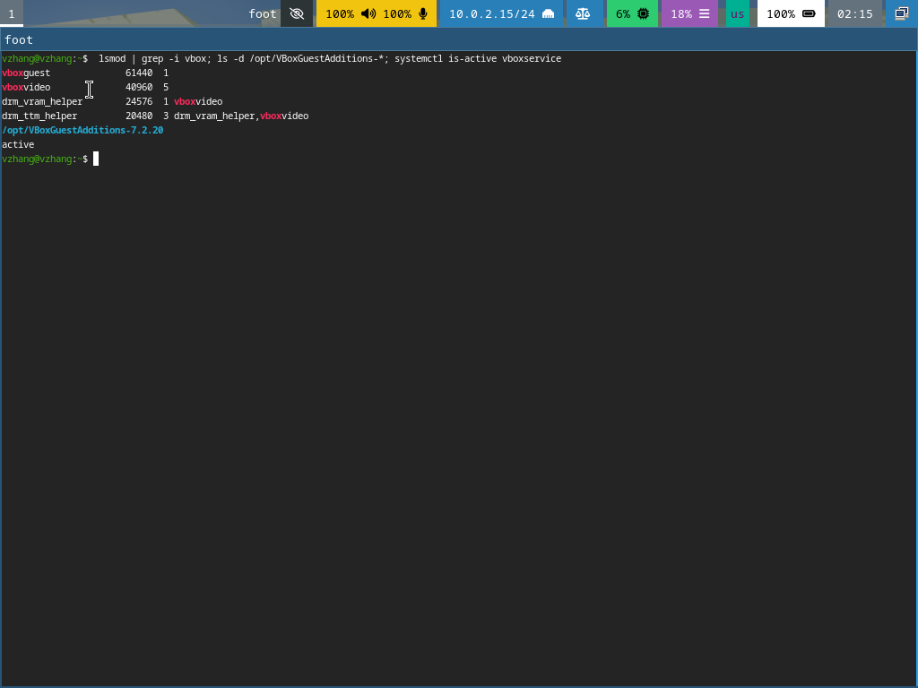

## Анализ загрузки: ядро и процессор

- Версия ядра: `6.19.10-300.fc44.x86_64`
- Частота процессора: 2611.210 МГц
- Модель процессора: 13th Gen Intel(R) Core(TM) i5-13420H

```bash
sudo dmesg | grep -iE 'linux version|detected.*mhz|CPU0:'
```

## Анализ загрузки: память и файловая система

- Доступная память: 3930732 КБ из 4193848 КБ
- Гипервизор: KVM
- Корневая файловая система: btrfs (подтом `root`)

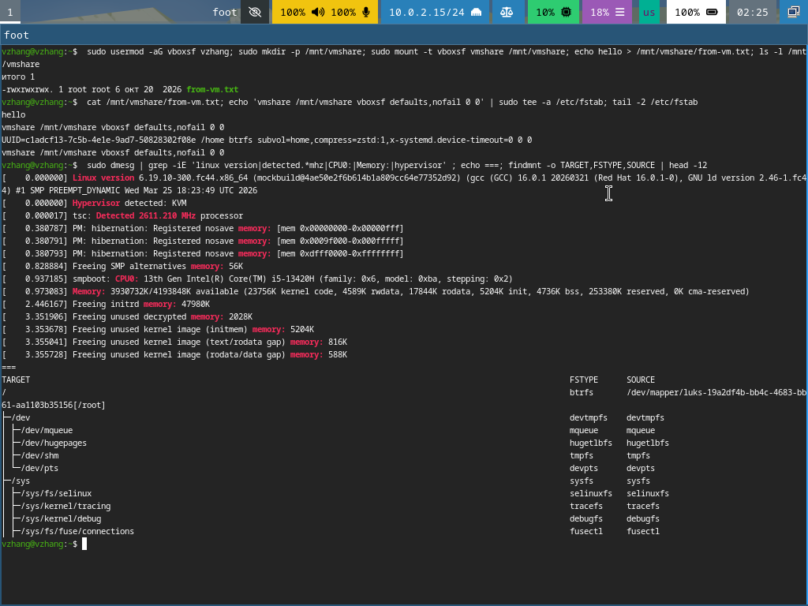

# Заключение

## Выводы

- Установлена Fedora Sway на виртуальную машину VirtualBox
- Выполнена первичная настройка системы
- Установлены дополнения гостевой ОС
- Получены сведения о ядре, процессоре, памяти и файловой системе
- Восстановлена последовательность монтирования файловых систем

## Спасибо за внимание!

Вопросы?